# Ejemplo 5

Paula Gutierrez Sanchez

29/10/2021

# Ejercicio 5

Una wedding planner (Profesional que se dedica a asistir a un cliente con el diseño, planificación y gestión de su boda). Le han contratado para una boda el 28 de febrero del 2021. La hacienda que han elegido los novios les da la opción de poder celebrar la boda al aire libre o cubierto dentro de la hacienda o incluso ambas cosas, dependerá del tiempo meteorológico.

En el caso de que sea al aire libre:

- Si llueve, la wedding planner pierde 10.000 euros porque tiene que cancelar la boda.
- Si está nublado, la wedding planner gana 20.000 euros ya que no se podrían realizar las fotos planeadas en el pack seleccionado.
- Si está soleado, la wedding planner gana 30.000 euros con el pack completo de boda planteado.

En el caso de que sea cubierto, hay menos capacidad para los invitados:

- Si llueve, la wedding planner gana 13.000 euros.
- Si está nublado, la wedding planner gana 10.000 euros porque puede realizar actividades fuera.
- Si está soleado, la wedding planner gana 25.000 euros ya que podría hacer el pack completo.

¿Qué opción es mejor para la wedding planner?

```r
tb05 = crea.tablaX(c(-10000,20000,30000,
                      13000,10000,25000), numalternativas = 2, numestados = 3)
tb05
```

```
##        e1    e2    e3
## d1 -10000 20000 30000
## d2  13000 10000 25000
```

```r
sol = criterio.Todos(tb05,alfa = 0.5,favorable = TRUE)
sol
```

```
##                     e1    e2    e3   Wald Optimista Hurwicz Savage Laplace
## d1              -10000 20000 30000 -10000     30000   10000  23000   13333
## d2               13000 10000 25000  10000     25000   17500  10000   16000
## iAlt.Opt (fav.)     --    --    --     d2        d1      d2     d2      d2
##                 Punto Ideal
## d1                    23000
## d2                    11180
## iAlt.Opt (fav.)          d2
```

Para el **criterio de Wald** la mejor alternativa es la d2 que en este caso es hacer la boda en una zona cubierta.

Para el **criterio Optimista** la mejor alternativa es la d1 que es en este caso hacer la boda al aire libre.

Para el **criterio de Hurwicz** la mejor alternativa es la d2 que en este caso es ahcer la boda en una zona cubierta.

Para el **criterio de Savage** la mejor alternativa es la d2 que es en este caso hacer la boda en una zona cubierta.

Para el **criterio de Laplace** la mejor alternativa es la d2 que es en este caso hacer la boda en una zona cubierta.

Para el **criterio de Punto Ideal** la mejor alternativa es la d2 que es en este caso hacer la boda en una zona cubierta.

Aplicamos el criterio de Hurwicz:

```r
sol05H = criterio.Hurwicz.General(tb05,alfa = 0.5,favorable = TRUE)
sol05H
```

```
## $criterio
## [1] "Hurwicz"
##
## $alfa
## [1] 0.5
##
## $metodo
## [1] "favorable"
##
## $tablaX
##        e1    e2    e3
## d1 -10000 20000 30000
## d2  13000 10000 25000
##
## $ValorAlternativas
##    d1    d2
## 10000 17500
##
## $ValorOptimo
## [1] 17500
##
## $AlternativaOptima
## d2
##  2
```

Para alfa = 0.5, la alternativa óptima sería d2 (Cubierto).

```r
sol05H1 = criterio.Hurwicz.General(tb05,alfa = 0.9,favorable = TRUE)
sol05H1
```

```
## $criterio
## [1] "Hurwicz"
##
## $alfa
## [1] 0.9
##
## $metodo
## [1] "favorable"
##
## $tablaX
##        e1    e2    e3
## d1 -10000 20000 30000
## d2  13000 10000 25000
##
## $ValorAlternativas
##    d1    d2
## 26000 23500
##
## $ValorOptimo
## [1] 26000
##
## $AlternativaOptima
## d1
##  1
```

Para alfa = 0.9, la alternativa óptima seria d1 (Aire libre).

```r
sol05H2 = criterio.Hurwicz.General(tb05,alfa = 0.7,favorable = TRUE)
sol05H2
```

```
## $criterio
## [1] "Hurwicz"
##
## $alfa
## [1] 0.7
##
## $metodo
## [1] "favorable"
##
## $tablaX
##        e1    e2    e3
## d1 -10000 20000 30000
## d2  13000 10000 25000
##
## $ValorAlternativas
##    d1    d2
## 18000 20500
##
## $ValorOptimo
## [1] 20500
##
## $AlternativaOptima
## d2
##  2
```

```r
Intervalo = Hurwicz.intervalos(tb05,favorable = TRUE)
```

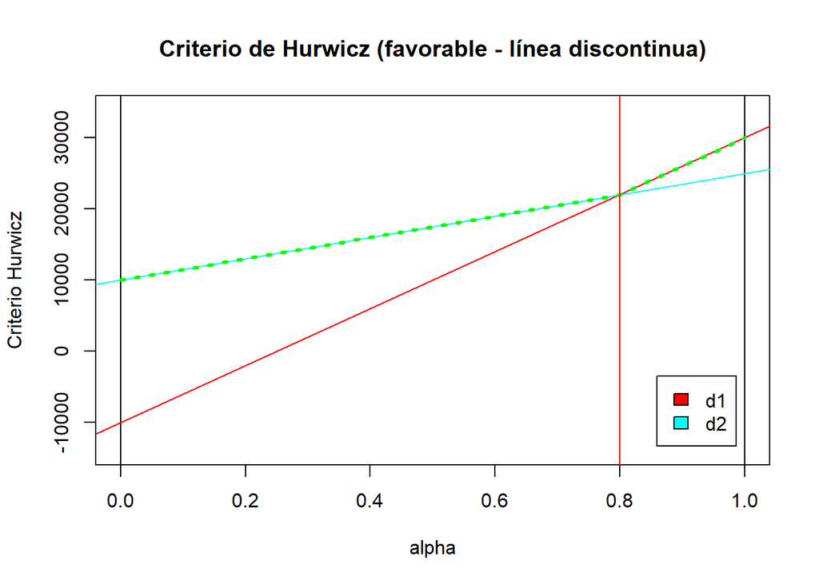

Como podemos observar en el gráfico, el punto que corta las dos rectas es cuando alpha vale 0.8.

```r
Intervalo
```

```
## $AltOptimas
## [1] 2 1
##
## $PuntosDeCorte
## [1] 0.8
##
## $IntervalosAlfa
##      Intervalo     Alternativa
## [1,] "( 0 , 0.8 )" "2"
## [2,] "( 0.8 , 1 )" "1"
```

Los valores de alpha que determinan los intervalos dónde cambian las alternativas óptimas en este caso seria 0.8.

El intervalo para la alternativa d1 que es en este caso al aire libre es : (0.8,1), esto quiere decir que cuando alpha este dentro de este intervalo la mejor alternativa va a ser d1, al aire libre.

El intervalo para la alternativa d2 que es en este caso cubierto es : (0,0.8), esto quiere decir que cuando alpha este dentro de este intervalo la mejor alternativa va a ser d2, cubierto.